# Weekly Data Science 160228 : 서울시 대기오염도 분석

mino

2016년 2월 28일

## 0. 라이브러리

```r
library(dplyr)
```

```r
library(ggplot2)
```

## 1. 데이터

### 1.1 데이터 출처

[서울시 일별 평균 대기오염도 정보](http://data.seoul.go.kr/openinf/sheetview.jsp?infId=OA-2218&tMenu=11)

[서울특별시 대기환경정보](http://cleanair.seoul.go.kr)

### 1.2 데이터 불러오기

```r
seoul_daily_air = readr::read_csv('data/서울시일별평균대기오염도정보.csv',  skip = 1)
weather = readr::read_csv('data/weather.csv')
```

### 1.3 데이터 설명

```r
summary(seoul_daily_air)
```

```
##     MSRDT_DE         MSRSTE_NM              NO2                O3
##  Min.   :20150227   Length:14362       Min.   :0.00300   Min.   :0.00000
##  1st Qu.:20150527   Class :character   1st Qu.:0.02600   1st Qu.:0.01100
##  Median :20150826   Mode  :character   Median :0.03600   Median :0.01800
##  Mean   :20152236                      Mean   :0.03823   Mean   :0.01995
##  3rd Qu.:20151127                      3rd Qu.:0.04900   3rd Qu.:0.02700
##  Max.   :20160227                      Max.   :0.16900   Max.   :0.09200
##                                        NA's   :39        NA's   :39
##        CO               SO2               PM10             PM25
##  Min.   : 0.0000   Min.   :0.00000   Min.   :  3.00   Min.   : 2.0
##  1st Qu.: 0.4000   1st Qu.:0.00400   1st Qu.: 30.00   1st Qu.:15.0
##  Median : 0.5000   Median :0.00500   Median : 41.00   Median :21.0
##  Mean   : 0.5649   Mean   :0.00562   Mean   : 44.77   Mean   :23.5
##  3rd Qu.: 0.7000   3rd Qu.:0.00700   3rd Qu.: 54.00   3rd Qu.:29.0
##  Max.   :25.1000   Max.   :0.02700   Max.   :215.00   Max.   :85.0
##  NA's   :52        NA's   :53        NA's   :67       NA's   :55
```

- MSRDT_DE : 측정일시
- MSRSTE_NM : 측정소명
- NO2 : 이산화질소농도(ppm)
- O3 : 오존농도(ppm)
- CO : 일산화탄소농도(ppm)
- SO2 : 아황산가스(ppm)
- PM10 : 미세먼지
- PM25 : 초미세먼지

## 2. EDA

### 2.1 측정소별 평균

NA값이 섞이면 평균 계산이 안되기 때문에 `na.rm = TRUE` 옵션을 추가해준다

```r
seoul_eda_mean = seoul_daily_air %>%
  select(-MSRDT_DE) %>%
  group_by(MSRSTE_NM) %>%
  summarise_each(funs(mean(., na.rm = TRUE)))

seoul_eda_mean
```

```
## Source: local data frame [40 x 7]
##
##    MSRSTE_NM        NO2         O3        CO         SO2     PM10     PM25
##        (chr)      (dbl)      (dbl)     (dbl)       (dbl)    (dbl)    (dbl)
## 1     강남구 0.03396986 0.02161749 0.4519126 0.005229508 42.98087 22.27596
## 2     강동구 0.03144262 0.02026776 0.5144809 0.004568306 42.43443 21.18852
## 3   강변북로 0.05256011 0.01348634 0.5868852 0.005016393 46.44199 23.06284
## 4     강북구 0.02993003 0.02194169 0.4725948 0.004650146 39.89796 22.85714
## 5     강서구 0.02954918 0.02273224 0.4265027 0.005950820 45.22192 23.60109
## 6     공항로 0.03510929 0.01540274 0.6457534 0.005795082 65.88385 29.03662
## 7     관악구 0.03536612 0.02298630 0.6252055 0.004754098 47.47268 26.50959
## 8     광진구 0.03085246 0.02118306 0.5224044 0.004598361 42.28219 22.88767
## 9     구로구 0.02756438 0.02593973 0.5528767 0.006153425 42.80274 23.13151
## 10    금천구 0.03347006 0.02005341 0.5540059 0.005661721 43.78635 27.03858
## ..       ...        ...        ...       ...         ...      ...      ...
```

#### pairs

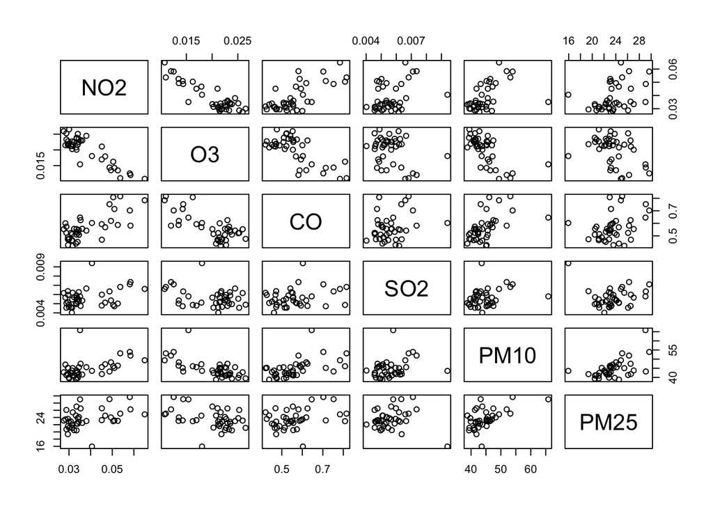

```r
plot(seoul_eda_mean[,-1])
```

#### 평행좌표계

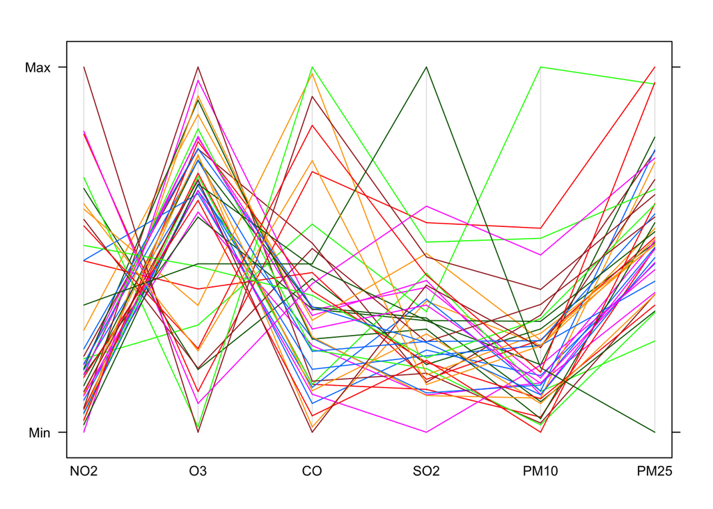

```r
lattice::parallelplot(seoul_eda_mean[,-1], horizontal.axis = FALSE)
```

- NO2와 O3를 기준으로 뚜렷하게 구분되는 항목들이 존재한다
- NO2와 O3에 음의 상관관계? 로 추정되는 현상이 보인다

### 2.1.1 O3를 기준으로 구분

이를 바탕으로 항목들을 구분해보는 것도 좋을 듯

```r
seoul_eda_mean_divO3 = seoul_eda_mean %>%
  mutate(o3_mid = (min(O3) + max(O3))/2,
         o3_upper = O3 > o3_mid)

seoul_eda_mean_divO3
```

```
## Source: local data frame [40 x 9]
##
##    MSRSTE_NM        NO2         O3        CO         SO2     PM10     PM25
##        (chr)      (dbl)      (dbl)     (dbl)       (dbl)    (dbl)    (dbl)
## 1     강남구 0.03396986 0.02161749 0.4519126 0.005229508 42.98087 22.27596
## 2     강동구 0.03144262 0.02026776 0.5144809 0.004568306 42.43443 21.18852
## 3   강변북로 0.05256011 0.01348634 0.5868852 0.005016393 46.44199 23.06284
## 4     강북구 0.02993003 0.02194169 0.4725948 0.004650146 39.89796 22.85714
## 5     강서구 0.02954918 0.02273224 0.4265027 0.005950820 45.22192 23.60109
## 6     공항로 0.03510929 0.01540274 0.6457534 0.005795082 65.88385 29.03662
## 7     관악구 0.03536612 0.02298630 0.6252055 0.004754098 47.47268 26.50959
## 8     광진구 0.03085246 0.02118306 0.5224044 0.004598361 42.28219 22.88767
## 9     구로구 0.02756438 0.02593973 0.5528767 0.006153425 42.80274 23.13151
## 10    금천구 0.03347006 0.02005341 0.5540059 0.005661721 43.78635 27.03858
## ..       ...        ...        ...       ...         ...      ...      ...
## Variables not shown: o3_mid (dbl), o3_upper (lgl)
```

O3값을 기준으로 색상을 나누어서 평행좌표계를 다시 그린다

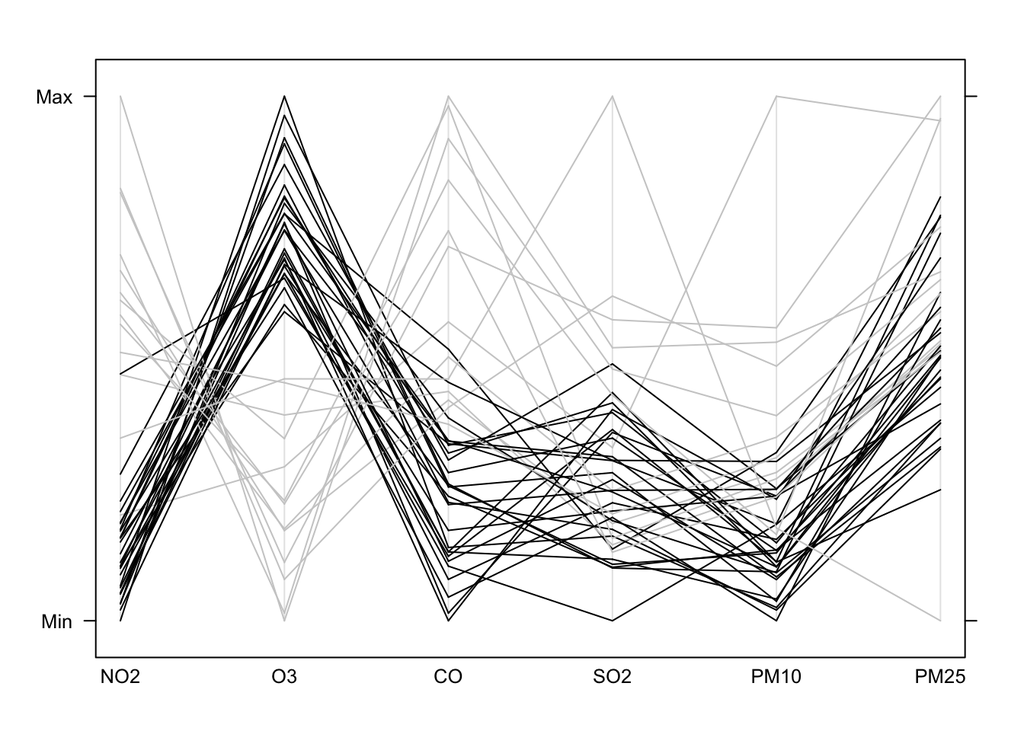

```r
seoul_eda_mean_divO3 %>%
  select(-MSRSTE_NM,-o3_mid, -o3_upper) %>%
  lattice::parallelplot(
    horizontal.axis = FALSE,
    col = ifelse(seoul_eda_mean_divO3$o3_upper == TRUE, 'black', '#cccccc')
  )
```

#### O3가 높은 곳들은 어떤 곳일까?

```r
seoul_eda_mean_divO3 %>%
  filter(o3_upper == TRUE) %>%
  print(n=30)
```

```
## Source: local data frame [27 x 9]
##
##    MSRSTE_NM        NO2         O3        CO         SO2     PM10     PM25
##        (chr)      (dbl)      (dbl)     (dbl)       (dbl)    (dbl)    (dbl)
## 1     강남구 0.03396986 0.02161749 0.4519126 0.005229508 42.98087 22.27596
## 2     강동구 0.03144262 0.02026776 0.5144809 0.004568306 42.43443 21.18852
## 3     강북구 0.02993003 0.02194169 0.4725948 0.004650146 39.89796 22.85714
## 4     강서구 0.02954918 0.02273224 0.4265027 0.005950820 45.22192 23.60109
## 5     관악구 0.03536612 0.02298630 0.6252055 0.004754098 47.47268 26.50959
## 6     광진구 0.03085246 0.02118306 0.5224044 0.004598361 42.28219 22.88767
## 7     구로구 0.02756438 0.02593973 0.5528767 0.006153425 42.80274 23.13151
## 8     금천구 0.03347006 0.02005341 0.5540059 0.005661721 43.78635 27.03858
## 9   내부순환 0.03803581 0.02446556 0.5417582 0.006653846 45.60221 23.00556
## 10    노원구 0.02946556 0.02181044 0.4725275 0.006359890 41.80769 19.36538
## 11    도봉구 0.03005738 0.02651639 0.4759563 0.004887978 39.46154 21.11749
```

[output cut: 17 more lines]

#### O3가 낮은 곳들은 어떤 곳일까?

```r
seoul_eda_mean_divO3 %>%
  filter(o3_upper == FALSE)
```

```
## Source: local data frame [13 x 9]
##
##    MSRSTE_NM        NO2         O3        CO         SO2     PM10     PM25
##        (chr)      (dbl)      (dbl)     (dbl)       (dbl)    (dbl)    (dbl)
## 1   강변북로 0.05256011 0.01348634 0.5868852 0.005016393 46.44199 23.06284
## 2     공항로 0.03510929 0.01540274 0.6457534 0.005795082 65.88385 29.03662
## 3       길동 0.04514050 0.01695592 0.5933884 0.004798898 45.63361 23.26722
## 4   동작대로 0.05812877 0.01253552 0.7024590 0.007106557 53.91803 29.67760
## 5     서울역 0.04939071 0.01354098 0.6193989 0.005352459 48.26230 24.03030
## 6     신사동 0.05044828 0.01624713 0.8082840 0.004865854 46.11816 22.97126
## 7       신촌 0.05369126 0.01101366 0.8155738 0.006819672 53.17260 25.07671
## 8   양재대로 0.06501639 0.01078415 0.7836066 0.006601093 49.37705 24.87158
## 9     영등포 0.05843251 0.01202479 0.5812672 0.007349862 51.93664 26.25069
## 10      종로 0.04672802 0.01792562 0.5686813 0.005115385 47.20879 24.50824
## 11    청계천 0.04060656 0.01804098 0.6027701 0.009398907 43.56868 15.93169
## 12    청량리 0.04872951 0.01438798 0.7524590 0.006333333 43.23224 29.09290
## 13      태릉 0.05098619 0.01428729 0.7143646 0.004722222 45.18785 23.18785
## Variables not shown: o3_mid (dbl), o3_upper (lgl)
```

강변북로, 공항로, 길동, 동작대로, 서울역, 신사동, 신촌, 양재대로, 영등포, 종로, 청계천, 청량리, 태릉

구 단위로 되어있는 측정소에 비해 구 단위가 아닌 측정소가 대체로 더 낮은 오존 수치를 보이는 것 같다

왜그럴까??????

우선 현재까지의 상황을 정리해보면

- 서울특별시 대기환경정보에서 제공하는 측정소(구단위)는 25개
- 오존이 중간 이상값에 해당하는 항목을 보면 25개 구단위 측정소 + 내부순환, 동대문 (총 27개)
- 구단위 측정소는 전부 오존수치가 비교적 높게 나오고 있다

[도심 관측소 설치기준? 에 관한 문의글](http://cleanair.seoul.go.kr/citizen.htm?method=qnaView&seq=577&lGroup=1&searchWord=&pNum=1)

- 대기오염 물질 관측소는 도로변 관측소와 도심 관측소로 나뉘어져 있다고 하며
- 통행량과 유동인구가 많은 도로변에 관측소를 설치한다고 함

이를 바탕으로 생각해보면

- 오존발생의 주원인은 자동차 배기가스일텐데 오히려 도로변이 낮다???
- 도심에는 차량들이 밀집되어있으며 이동하는 속도도 느리기 때문에 오히려 배출하는 배기가스는 많을 수도 있겠다

### 2.1.2 O3분포

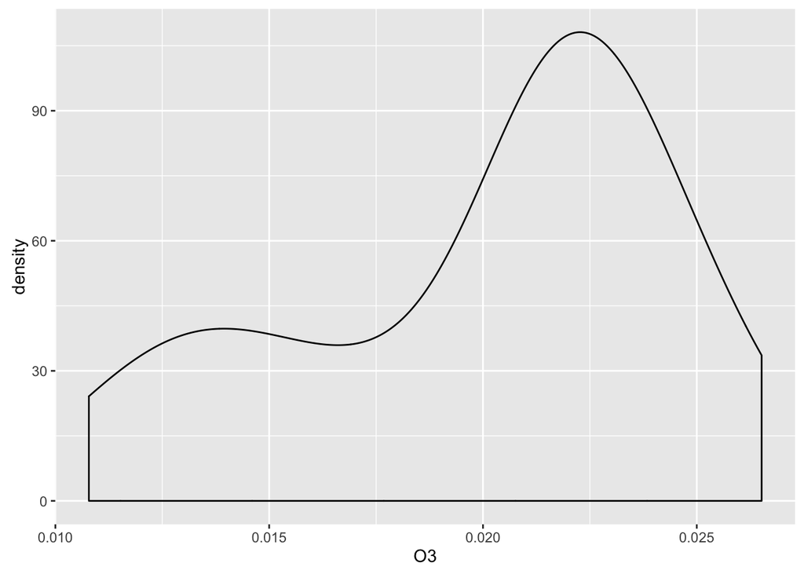

```r
seoul_eda_mean %>%
  ggplot(aes(x = O3)) +
    geom_density()
```

### 2.1.3 O3와 NO2의 상관관계

#### 전체

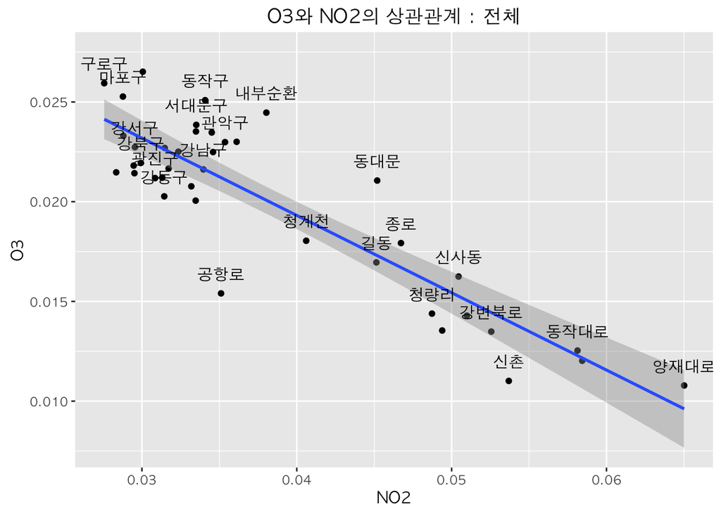

```r
seoul_eda_mean %>%
  ggplot(aes(x = NO2, y = O3)) +
    geom_point() +
    geom_smooth(method = 'lm') +
    geom_text(aes(label = MSRSTE_NM),
              check_overlap = TRUE, nudge_y = 0.001,
              family = 'AppleGothic') +
  ggtitle('O3와 NO2의 상관관계 : 전체') +
  theme_gray(base_family = 'AppleGothic')
```

O3를 기준으로 측정소를 구분했을 때와 비슷하게 항목들이 구분되었다.

어느 정도 음의 상관관계가 나타나고 있다

만약 두 그룹을 나누어서 비교해서 음의 상관관계가 나타날까???

#### o3_upper == TRUE인 항목만

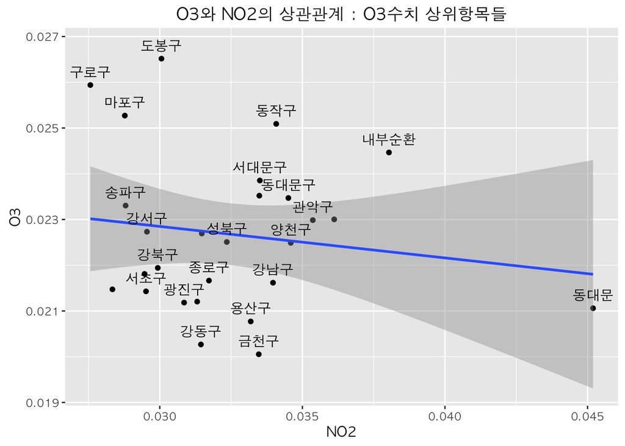

```r
seoul_eda_mean_divO3 %>%
  filter(o3_upper == TRUE) %>%
  ggplot(aes(x = NO2, y = O3)) +
    geom_point() +
    geom_smooth(method = 'lm') +
    geom_text(aes(label = MSRSTE_NM),
              check_overlap = TRUE, nudge_y = 0.0003,
              family = 'AppleGothic') +
    ggtitle('O3와 NO2의 상관관계 : O3수치 상위항목들') +
    theme_gray(base_family = 'AppleGothic')
```

여기서는 그닥 상관관계가 보이지 않는다

#### o3_upper == FALSE인 항목만

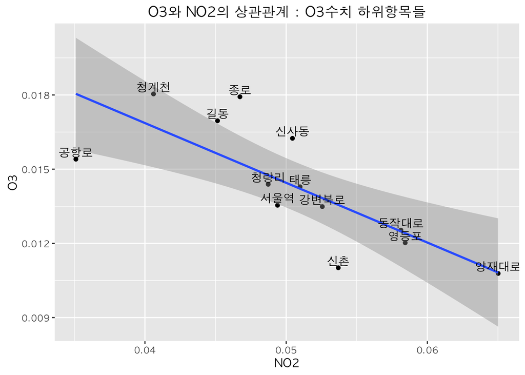

```r
seoul_eda_mean_divO3 %>%
  filter(o3_upper == FALSE) %>%
  ggplot(aes(x = NO2, y = O3)) +
  geom_point() +
  geom_smooth(method = 'lm') +
  geom_text(aes(label = MSRSTE_NM),
            check_overlap = TRUE, nudge_y = 0.0003,
            family = 'AppleGothic') +
  ggtitle('O3와 NO2의 상관관계 : O3수치 하위항목들') +
  theme_gray(base_family = 'AppleGothic')
```

여기에는 그래도 여전히 음의 상관관계가 보임

### 이유가 뭘까???

http://www.itc2000.co.kr/markes/markes5_1.html

지표 오존의 생성단계에 NO2가 사용되는 듯

- 공기중에 휘발성 유기화합물이 있거나,
- 고온 + 저습 + 약풍 + 일사량증가 등 조건이 겹치는 상황에서 오존이 많이 생성됨

기온이나 풍량 등의 **추가적인 데이터**가 필요할 듯

### 2.2 측정소별 시계열

#### 영등포구 시계열

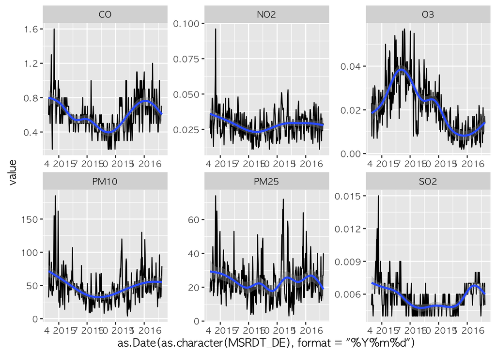

```r
seoul_daily_air %>%
  filter(MSRSTE_NM == '영등포구' ) %>%
  tidyr::gather(key = 'category', value = 'value', NO2:PM25) %>%
  ggplot(aes(x = as.Date(as.character(MSRDT_DE), format = '%Y%m%d'),
             y = value)) +
  geom_line() +
  geom_smooth() +
  facet_wrap( ~ category, scales = 'free') +
  theme_gray(base_family = 'AppleGothic')
```

## 3. (소)결론

결론이라기보다는 궁금한 점?